# Week 2: Class Exercise on Stationarity & Seasonality

```r
library(quantmod)
getSymbols("DJIA", src = "FRED",auto.assign=TRUE)  #-- takes ticker names and pulls data from FRED
```

[output not shown]

```
## [1] "DJIA"
```

```r
#default is 10 years back
class(DJIA)
```

```
## [1] "xts" "zoo"
```

```r
head(DJIA)
```

```
##               DJIA
## 2009-08-27 9580.63
## 2009-08-28 9544.20
## 2009-08-31 9496.28
## 2009-09-01 9310.60
## 2009-09-02 9280.67
## 2009-09-03 9344.61
```

```r
tail(DJIA)
```

```
##                DJIA
## 2019-08-19 26135.79
## 2019-08-20 25962.44
## 2019-08-21 26202.73
## 2019-08-22 26252.24
## 2019-08-23 25628.90
## 2019-08-26 25898.83
```

```r
class(DJIA) #notice it's a xts and zoo object
```

```
## [1] "xts" "zoo"
```

```r
head(DJIA, 100) #Can you spot the NAs?
```

```
##                DJIA
## 2009-08-27  9580.63
## 2009-08-28  9544.20
## 2009-08-31  9496.28
## 2009-09-01  9310.60
## 2009-09-02  9280.67
## 2009-09-03  9344.61
## 2009-09-04  9441.27
## 2009-09-07       NA
## 2009-09-08  9497.34
## 2009-09-09  9547.22
## 2009-09-10  9627.48
## 2009-09-11  9605.41
## 2009-09-14  9626.80
## 2009-09-15  9683.41
## 2009-09-16  9791.71
## 2009-09-17  9783.92
## 2009-09-18  9820.20
## 2009-09-21  9778.86
## 2009-09-22  9829.87
## 2009-09-23  9748.55
## 2009-09-24  9707.44
## 2009-09-25  9665.19
## 2009-09-28  9789.36
## 2009-09-29  9742.20
## 2009-09-30  9712.28
## 2009-10-01  9509.28
## 2009-10-02  9487.67
## 2009-10-05  9599.75
## 2009-10-06  9731.25
## 2009-10-07  9725.58
## 2009-10-08  9786.87
## 2009-10-09  9864.94
## 2009-10-12  9885.80
## 2009-10-13  9871.06
## 2009-10-14 10015.86
## 2009-10-15 10062.94
## 2009-10-16  9995.91
## 2009-10-19 10092.19
## 2009-10-20 10041.48
```

[output cut: 46 more lines]

```
## 2009-12-24 10520.10
## 2009-12-25       NA
## 2009-12-28 10547.08
## 2009-12-29 10545.41
## 2009-12-30 10548.51
## 2009-12-31 10428.05
## 2010-01-01       NA
## 2010-01-04 10583.96
## 2010-01-05 10572.02
## 2010-01-06 10573.68
## 2010-01-07 10606.86
## 2010-01-08 10618.19
## 2010-01-11 10663.99
## 2010-01-12 10627.26
## 2010-01-13 10680.77
```

Now we want to reformat this daily data - we still want a time series but we want to get rid of weekends and holidays

```r
library(zoo)
temp <- zoo(na.omit(DJIA))
mydj <- zoo(temp[1:length(temp)])
class(mydj)
```

```
## [1] "zoo"
```

```r
head(mydj)
```

```
## 2009-08-27 2009-08-28 2009-08-31 2009-09-01 2009-09-02 2009-09-03
##    9580.63    9544.20    9496.28    9310.60    9280.67    9344.61
```

```r
tail(mydj)
```

```
## 2019-08-19 2019-08-20 2019-08-21 2019-08-22 2019-08-23 2019-08-26
##   26135.79   25962.44   26202.73   26252.24   25628.90   25898.83
```

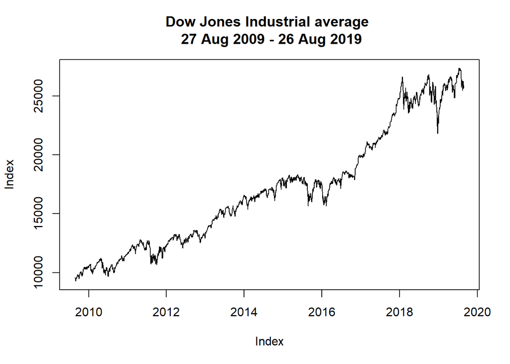

```r
plot(mydj, main = "Dow Jones Industrial average \n 27 Aug 2009 - 26 Aug 2019", ylab = "Index")
```

There is too much going on here - we will limit the series to the last year which is about 250 trading days

```r
tail(mydj, 250) #find out the start date for series
```

```
## 2018-08-24 2018-08-27 2018-08-28 2018-08-29 2018-08-30 2018-08-31
##   25790.35   26049.64   26064.02   26124.57   25986.92   25964.82
## 2018-09-04 2018-09-05 2018-09-06 2018-09-07 2018-09-10 2018-09-11
##   25952.48   25974.99   25995.87   25916.54   25857.07   25971.06
## 2018-09-12 2018-09-13 2018-09-14 2018-09-17 2018-09-18 2018-09-19
##   25998.92   26145.99   26154.67   26062.12   26246.96   26405.76
## 2018-09-20 2018-09-21 2018-09-24 2018-09-25 2018-09-26 2018-09-27
##   26656.98   26743.50   26562.05   26492.21   26385.28   26439.93
## 2018-09-28 2018-10-01 2018-10-02 2018-10-03 2018-10-04 2018-10-05
##   26458.31   26651.21   26773.94   26828.39   26627.48   26447.05
## 2018-10-09 2018-10-10 2018-10-11 2018-10-12 2018-10-15 2018-10-16
##   26430.57   25598.74   25052.83   25339.99   25250.55   25798.42
## 2018-10-17 2018-10-18 2018-10-19 2018-10-22 2018-10-23 2018-10-24
##   25706.68   25379.45   25444.34   25317.41   25191.43   24583.42
## 2018-10-25 2018-10-26 2018-10-29 2018-10-30 2018-10-31 2018-11-01
##   24984.55   24688.31   24442.92   24874.64   25115.76   25380.74
## 2018-11-02 2018-11-05 2018-11-06 2018-11-07 2018-11-08 2018-11-09
##   25270.83   25461.70   25635.01   26180.30   26191.22   25989.30
## 2018-11-13 2018-11-14 2018-11-15 2018-11-16 2018-11-19 2018-11-20
##   25286.49   25080.50   25289.27   25413.22   25017.44   24465.64
## 2018-11-21 2018-11-23 2018-11-26 2018-11-27 2018-11-28 2018-11-29
##   24464.69   24285.95   24640.24   24748.73   25366.43   25338.84
## 2018-11-30 2018-12-03 2018-12-04 2018-12-06 2018-12-07 2018-12-10
##   25538.46   25826.43   25027.07   24947.67   24388.95   24423.26
## 2018-12-11 2018-12-12 2018-12-13 2018-12-14 2018-12-17 2018-12-18
##   24370.24   24527.27   24597.38   24100.51   23592.98   23675.64
## 2018-12-19 2018-12-20 2018-12-21 2018-12-24 2018-12-26 2018-12-27
##   23323.66   22859.60   22445.37   21792.20   22878.45   23138.82
## 2018-12-28 2018-12-31 2019-01-02 2019-01-03 2019-01-04 2019-01-07
##   23062.40   23327.46   23346.24   22686.22   23433.16   23531.35
## 2019-01-08 2019-01-09 2019-01-10 2019-01-11 2019-01-14 2019-01-15
##   23787.45   23879.12   24001.92   23995.95   23909.84   24065.59
## 2019-01-16 2019-01-17 2019-01-18 2019-01-22 2019-01-23 2019-01-24
##   24207.16   24370.10   24706.35   24404.48   24575.62   24553.24
## 2019-01-25 2019-01-28 2019-01-29 2019-01-30 2019-01-31 2019-02-01
##   24737.20   24528.22   24579.96   25014.86   24999.67   25063.89
## 2019-02-04 2019-02-05 2019-02-06 2019-02-07 2019-02-08 2019-02-11
##   25239.37   25411.52   25390.30   25169.53   25106.33   25053.11
## 2019-02-12 2019-02-13 2019-02-14 2019-02-15 2019-02-19 2019-02-20
##   25425.76   25543.27   25439.39   25883.25   25891.32   25954.44
```

[output cut: 29 more lines]

```
##   26719.13   26727.54   26548.22   26536.82   26526.58   26599.96
## 2019-07-01 2019-07-02 2019-07-03 2019-07-05 2019-07-08 2019-07-09
##   26717.43   26786.68   26966.00   26922.12   26806.14   26783.49
## 2019-07-10 2019-07-11 2019-07-12 2019-07-15 2019-07-16 2019-07-17
##   26860.20   27088.08   27332.03   27359.16   27335.63   27219.85
## 2019-07-18 2019-07-19 2019-07-22 2019-07-23 2019-07-24 2019-07-25
##   27222.97   27154.20   27171.90   27349.19   27269.97   27140.98
## 2019-07-26 2019-07-29 2019-07-30 2019-07-31 2019-08-01 2019-08-02
##   27192.45   27221.35   27198.02   26864.27   26583.42   26485.01
## 2019-08-05 2019-08-06 2019-08-07 2019-08-08 2019-08-09 2019-08-12
##   25717.74   26029.52   26007.07   26378.19   26287.44   25897.71
## 2019-08-13 2019-08-14 2019-08-15 2019-08-16 2019-08-19 2019-08-20
##   26279.91   25479.42   25579.39   25886.01   26135.79   25962.44
## 2019-08-21 2019-08-22 2019-08-23 2019-08-26
##   26202.73   26252.24   25628.90   25898.83
```

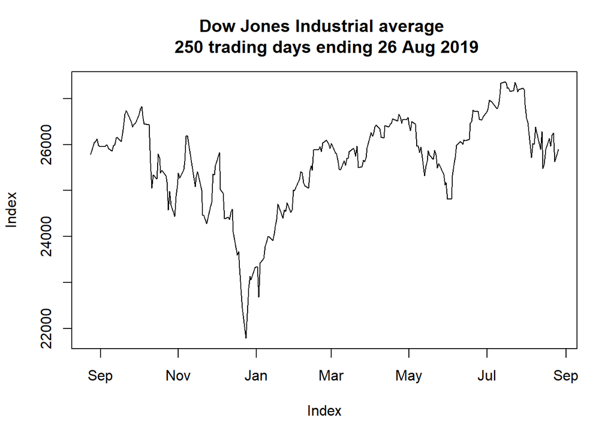

```r
mydj.short <- window(mydj, start = as.Date("2018-08-24")) #note the indexes - you can change this if you want

plot(mydj.short, main = "Dow Jones Industrial average \n 250 trading days ending 26 Aug 2019",  ylab = "Index")
```

```r
mydj.short.coredata <- coredata(mydj.short)
```

Can you examine the moments of this time series? Feel free to use plots & statistical tests.

Should we detrend the series?

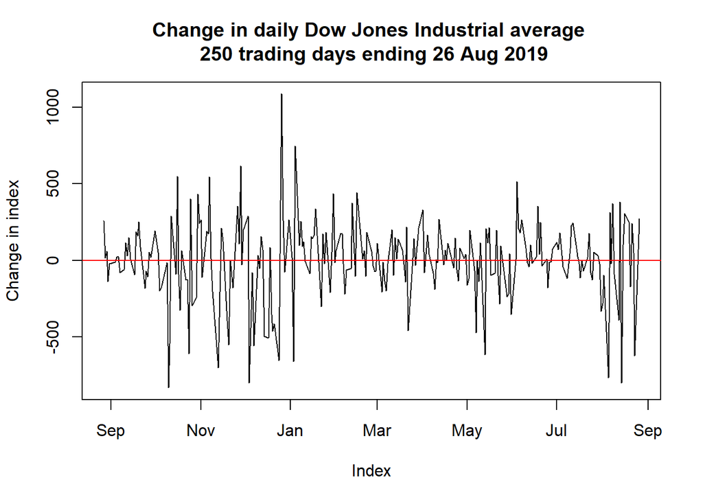

```r
#create the change in the DJ
diff_mydj <- diff(mydj.short)
plot(diff_mydj, main = "Change in daily Dow Jones Industrial average \n 250 trading days ending 26 Aug 2019", ylab = "Change in index")
abline(a=0,b=0, col = "red")
```

Okay, data munging and initial charting done. Is this series white noise? We’ll look at a picture and calculate a Ljung Box statistic which requires that we choose lag length (h) to test.

How do you choose h? FPP suggests h=10 for non-seasonal data, and h=2*m for seasonal data. Hyndman describes his reasoning here: http://robjhyndman.com/hyndsight/ljung-box-test/

There are other arguments for other choices. For example, see http://stats.stackexchange.com/questions/6455/how-many-lags-to-use-in-the-ljung-box-test-of-a-time-series

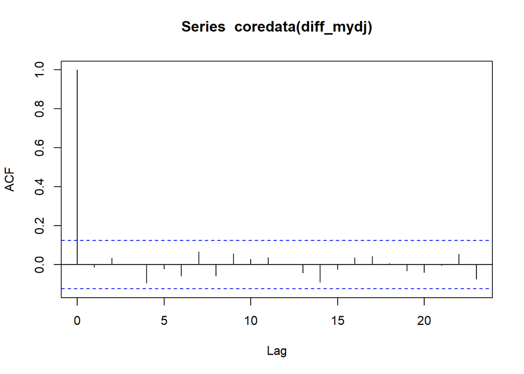

```r
acf(coredata(diff_mydj), plot=T) #note that the acf function only work with core data (i.e. no time index).
```

```r
#now calculate the test statistic
Box.test(diff_mydj, lag=10, fitdf=0, type="Lj")
```

```
##
##  Box-Ljung test
##
## data:  diff_mydj
## X-squared = 16.91, df = 10, p-value = 0.07638
```

So, is this white noise? Remember we are dealing with a null hypothesis of no serial correlation. If we get a pvalue greater than our threshhold (say 5% for 95% confidence), then we fail to reject the null.

Now: more on time series decomposition from week 1. The R commands are very simple. Here are the ones used to generate the charts in the slides:

```r
library(fpp2) #this is the package for the textbook
```

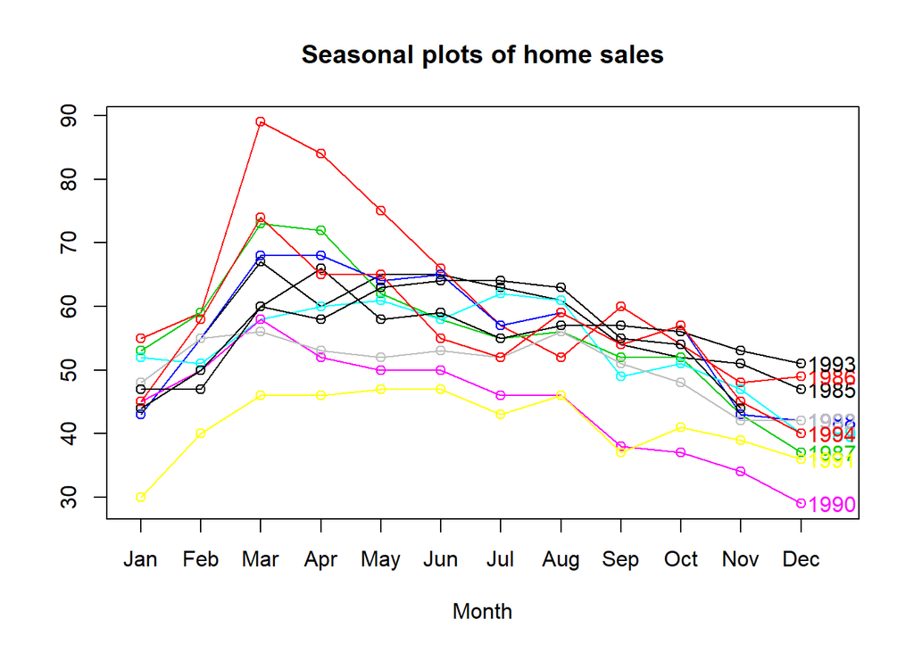

```r
#hsales data set is in fpp2 package
library(forecast)
seasonplot(window(hsales,start = 1985), year.labels = TRUE, col = 1:10, main = "Seasonal plots of home sales") #narrower window
```

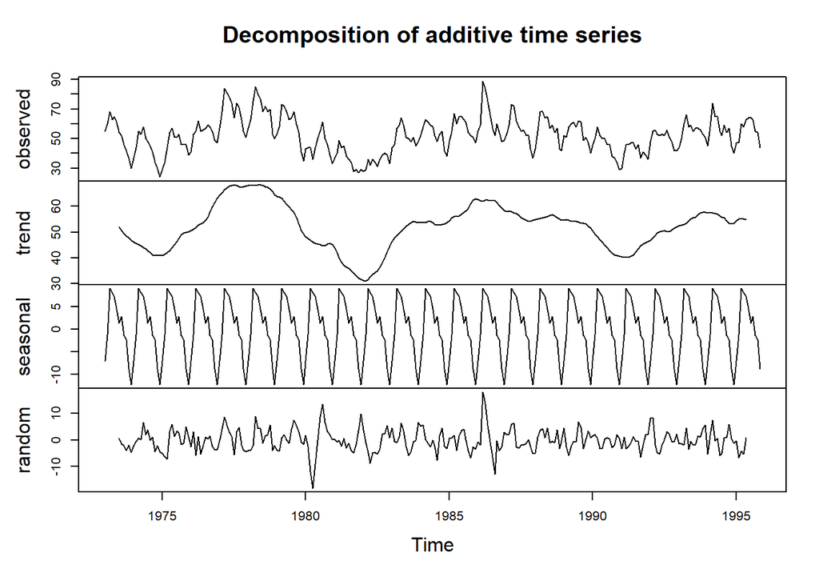

```r
plot(decompose(hsales)) #data set is from package
```

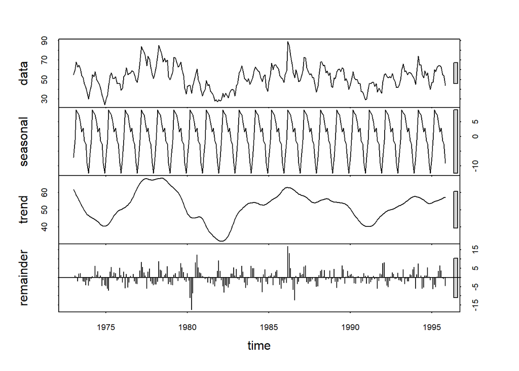

```r
plot(stl(hsales,s.window="periodic"))
```

Similar but different calculations. You can pull the pieces out of the decomposition process

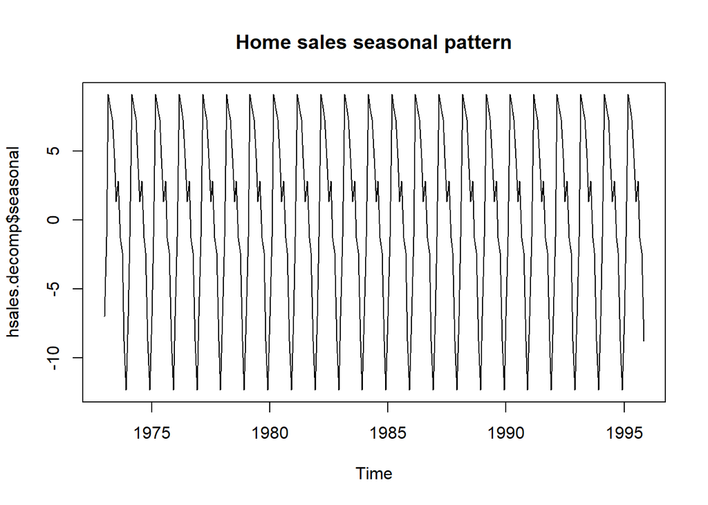

```r
hsales.decomp <- decompose(hsales)
plot(hsales.decomp$seasonal, main = "Home sales seasonal pattern")
```

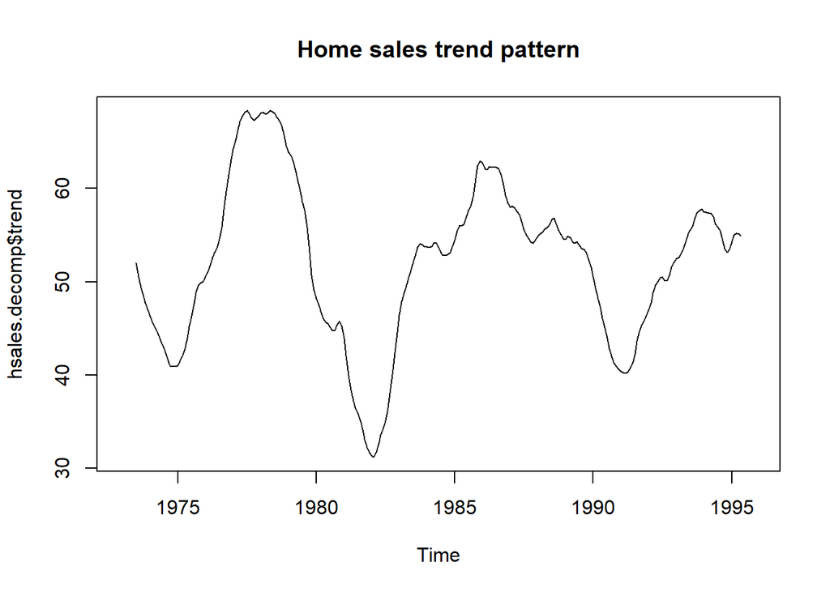

```r
plot(hsales.decomp$trend, main = "Home sales trend pattern")
```

#Unemployment Rate Example

Now we will decompose the unemployment rate.

Get data from FRED. Note the convoluted way that the time series item is created. The stl package requires a particular shape to the time series that doesn’t always result from the ts command. Note the differences in the dimensions and the description in the “Environment” window.

```r
urates <- c("UNRATENSA", "UNRATE")
getSymbols(urates, src="FRED")  #-- takes ticker names and pulls data from FRED
```

```
## [1] "UNRATENSA" "UNRATE"
```

```r
start(UNRATENSA)
```

```
## [1] "1948-01-01"
```

```r
end(UNRATENSA)
```

```
## [1] "2019-07-01"
```

```r
class(UNRATENSA)
```

```
## [1] "xts" "zoo"
```

```r
#suggestions for improving the 2 step process of creating a time series element with the correct dimensions are welcome

#first series
temp <- ts(UNRATENSA)
dim(temp)
```

```
## [1] 859   1
```

```r
ur.nsa <- ts(temp[1:823], start = c(1948,1), end = c(1948, length(UNRATENSA)),frequency = 12)
dim(ur.nsa)
```

[output not shown]

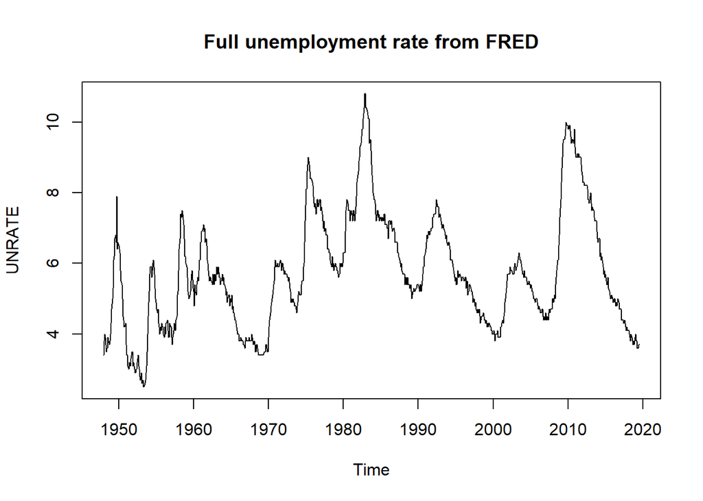

```r
#second series
temp <- ts(UNRATE)
ur<- ts(temp, start = c(1948,1), end = c(1948, length(UNRATE)), frequency = 12)

plot(ur, main = "Full unemployment rate from FRED")
```

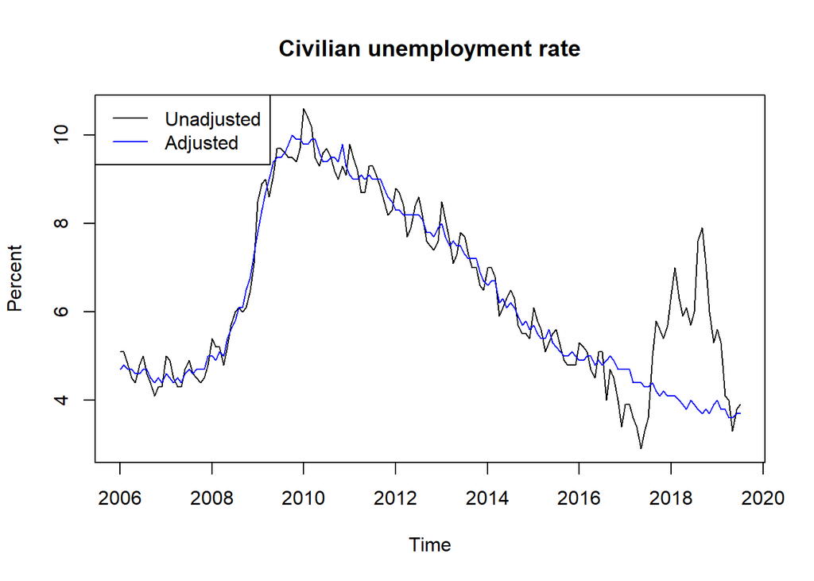

```r
ur.nsa.short <- window(ur.nsa, start = 2006)
ur.short <- window(ur, start = 2006)

plot(ur.nsa.short, ylab = "Percent", main = "Civilian unemployment rate")
lines(ur.short, col = "blue")
legend("topleft", legend=c("Unadjusted","Adjusted"), col=c("black","blue"), lty = 1)
```

Now to compare the decomposition. Note: you cannot pass a title to the plot from decompose command without writing a convoluted wrapper function which is too painful for me.

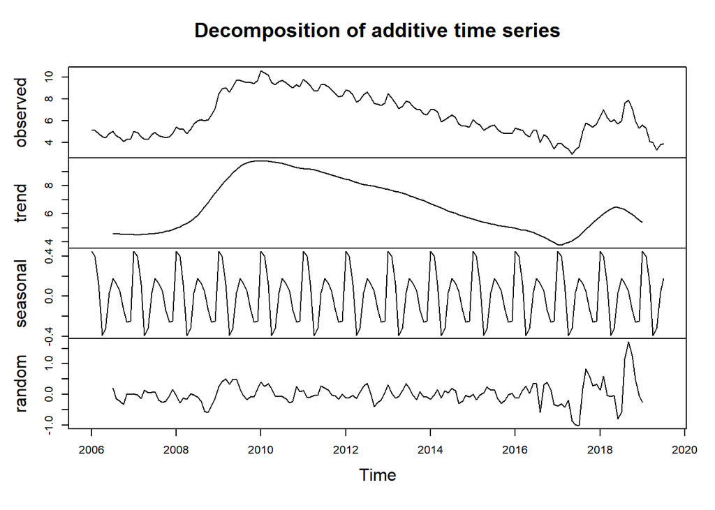

```r
plot(decompose(ur.nsa.short))
```

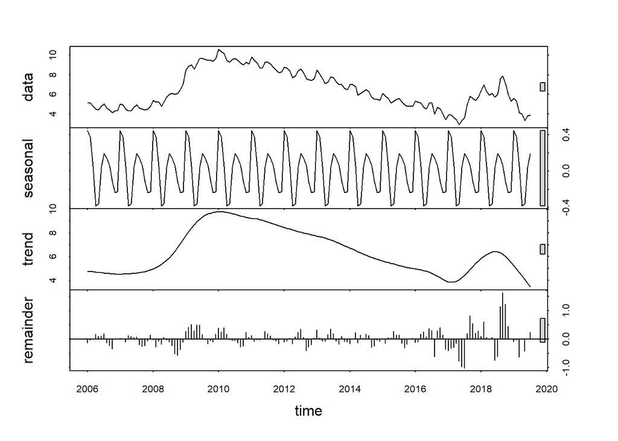

```r
plot(stl(ur.nsa.short, s.window = "periodic"))
```

Let’s compare the seasonal calculations:

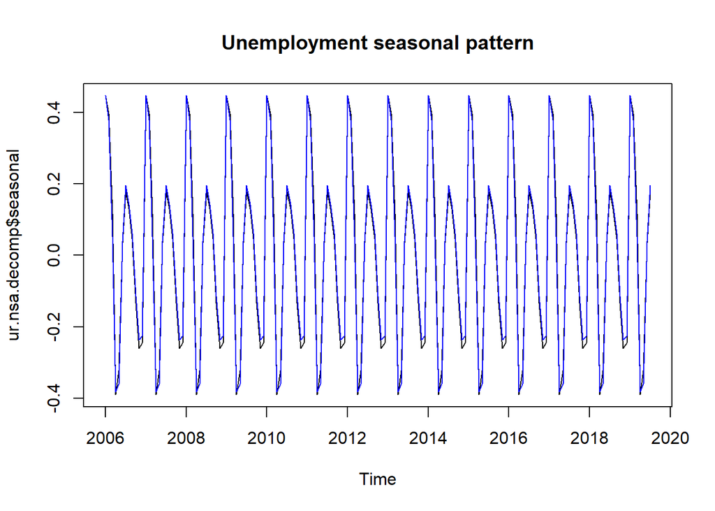

```r
ur.nsa.decomp <- decompose(ur.nsa.short)
ur.nsa.stl <- stl(ur.nsa.short, s.window = "periodic")

plot(ur.nsa.decomp$seasonal, main = "Unemployment seasonal pattern")
lines(ur.nsa.stl$time.series[,1], col = "blue")
```

We can also use the seasadj command to take either of these seasonal factors and adjust the unadjusted rate. How does that compare to the published rate?

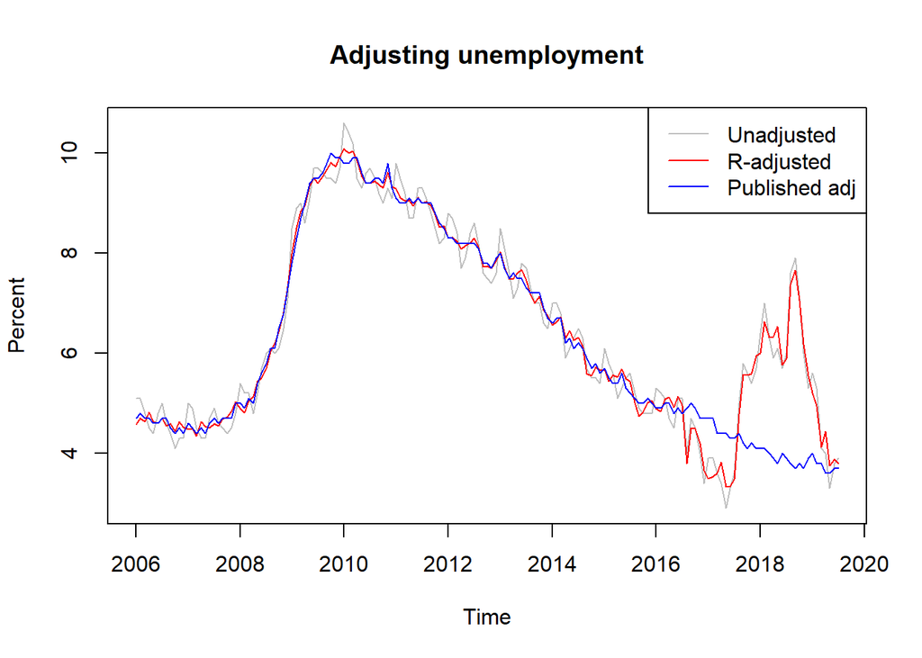

```r
#decomposition first, then adjustment
fit <- stl(ur.nsa.short,s.window=15)
ur.nsa.short.sa <- seasadj(fit)

#let's see the results

plot(ur.nsa.short, col="gray", ylab = "Percent", main = "Adjusting unemployment")
fit <- stl(ur.nsa.short,s.window=15)
ur.nsa.short.sa <- seasadj(fit)
lines(ur.nsa.short.sa, col="red")
lines(ur.short, col = "blue")
legend("topright", legend=c("Unadjusted","R-adjusted","Published adj"), col=c("grey", "red", "blue"), lty = c(1,1,1))
```